[News](http://diarsproject.github.io/DIARS/News.html)

[About](http://diarsproject.github.io/DIARS/About.html)

# Hyperspectral data processing

### *What are hyperspectral images?*

Hyperspectral sensors provide optical radiance data in >200 channels from 350-2500 nm with a spectral resolution of < 10 nm, generating images of contiguous spectral channels often spanning 400–1050 nm (visible to near-infrared) or 400–2500 nm (visible to shortwave-infrared) wavelength range (Figure 1), that can be use to characterize the chemistry of the vegetation, and allow a better discrimination between subtle physiological differences among plant species.

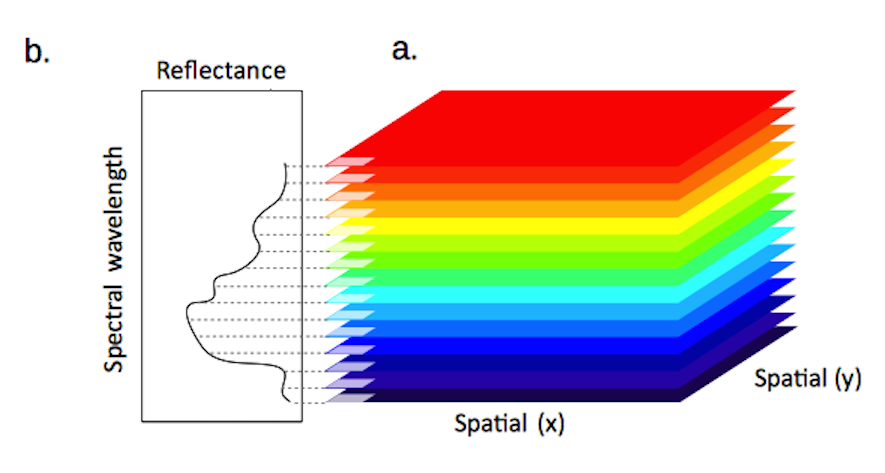

Figure 1. Hyperspectral image is composed by a large number of narrow spectral bands (a) that results in a spectral curve (b) for each image pixel.

### *What types of variables can be extracted from hyperspectral data?*

Hyperspectral data allows to trace, via spectral separability, subtle differences in the leaf pigment, nutrient and structural properties of the vegetation at different levels of aggregation. Such group-specific spectral properties are known as reflectance signatures that can be use to map and monitor vegetation changes from above.

Hyperspectral data has multiple applications, from allowing the differentiation between bare ground and ground with vegetation cover, and invasive vs. native species, to the accurate identification and mapping of single invasive and native species.

##### The dataset

To create the dataset provided in this section of the tutorial, we generated an artificial hyperspectral image (Figure 2) from the original [APEX data](http://www.apex-esa.org/content/apex) of Sylt island (Germany) collected and preprocessed by the Flemish Institute for Technological Research [VITO](http://diars.vgt.vito.be/content/home). The artificial image was created by taking a buffer area from the center of the calibration, validation and background points, and then rearranging the buffer squares together with the corresponding points, which resulted in an image with the real hyperspectral values (grid cells) at each point but reorganize in a smaller file (Figure 3). You can download the dataset for this tutorial from HERE.

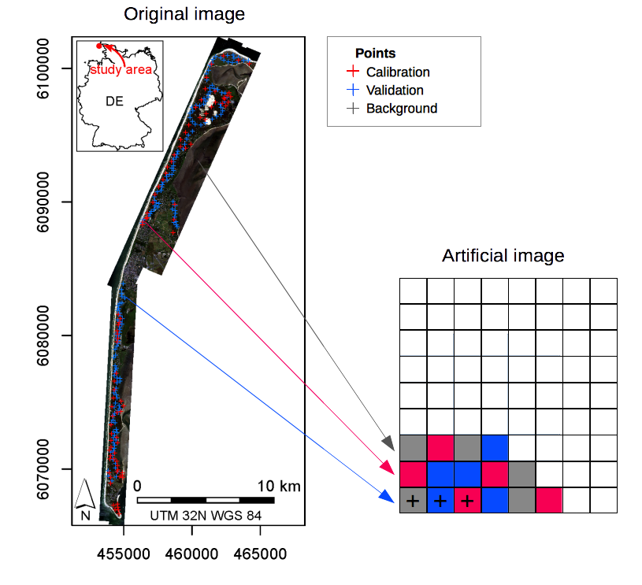

Figure 2. Creating the artificial image.

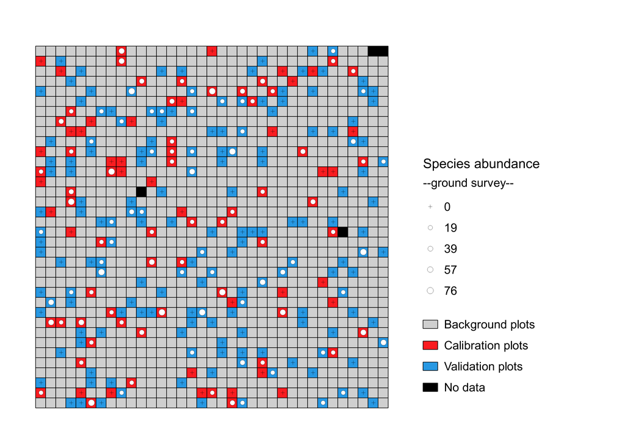

Figure 3. Description of the artificial image.

##### Setting up GRASS GIS within R

It is recommended to first create a folder where the hyperspectral image is located and the outputs and results are saved. Now you can set the working directory in R using the folder you just created:

```r
setwd("/home/garzonc/DIARS/")
```

Load the `rgrass7` library and create a directory that will contain the GRASS GISDBASE for the working session:

```r
library(rgrass7)
dir.create("grassdata")
```

```r
myGRASS <- "/home/garzonc/src/grass7_trunk/dist.x86_64-pc-linux-gnu"
myGISDbase <- "/home/garzonc/Documents/grassData"  #Set the directory path to your GISDbase
myLocation <- "DIARS"  #Name the Location
myMapset <- "PERMANENT"  #Name the mapset

initGRASS(myGRASS, home = tempdir(), gisDbase = myGISDbase, location = myLocation,
    mapset = myMapset, override = TRUE)
```

```
## gisdbase    /home/garzonc/Documents/grassData
## location    DIARS
## mapset      PERMANENT
## rows        170
## columns     185
## north       6080249
## south       6079943
## west        463975.2
## east        464308.2
## nsres       1.8
## ewres       1.8
## projection  +proj=utm +no_defs +zone=32 +a=6378137 +rf=298.257223563
## +towgs84=0.000,0.000,0.000 +to_meter=1
```

```r
execGRASS("g.region", parameters = list(n = "6080248.8", s = "6079942.8", e = "464308.2",
    w = "463975.2", res = "1.8"))
```

##### Importing the hyperspectral data into R

The image provided is ready to use, so you can import it directly into R. Remember to have the image stored in a new folder you created at the beginning of this tutorial. To manage this image (raster file) in R is necessary to install and load the `raster`package:

```r
library(raster)
```

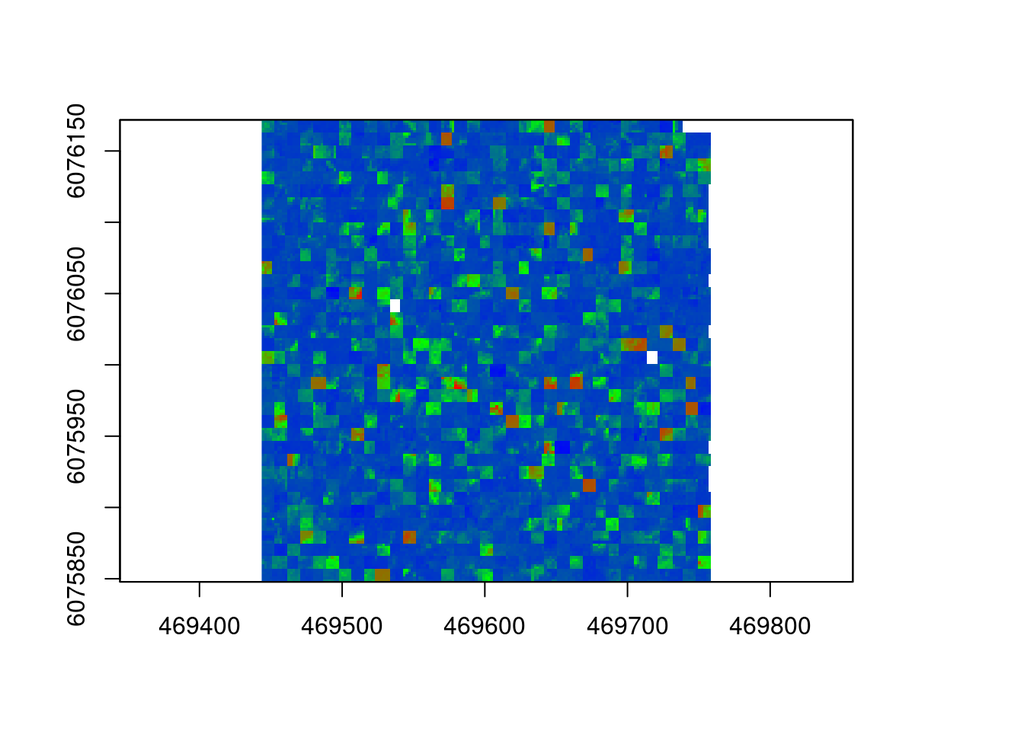

```r
setwd("/home/garzonc/Desktop/DIARS/")
filelist <- dir(pattern = ".tiff")
mo <- raster(filelist[5], band = 150, package = "raster")
plot(mo, col = colorRampPalette(c("blue", "green", "red"))(255), legend = FALSE)
```

##### Exploring the hyperspectral data

Hyperspectral images have many advantages due to the large amount of information contained in each pixel (in this case 248 bands). Lets visualize how all these data might look like. To do that first lets install the `raster`, `rgdal` and `foreach`:

```r
library(raster)
library(rgdal)
library(foreach)
```

Now lets extract a sample of the bands using the point dataset provided. First, import the point dataset. Lets plot the curve of spectral responses for a sample calibration and background points, that is, the percent reflectance values per point across the range of wavelengths in the hyperspectral image.

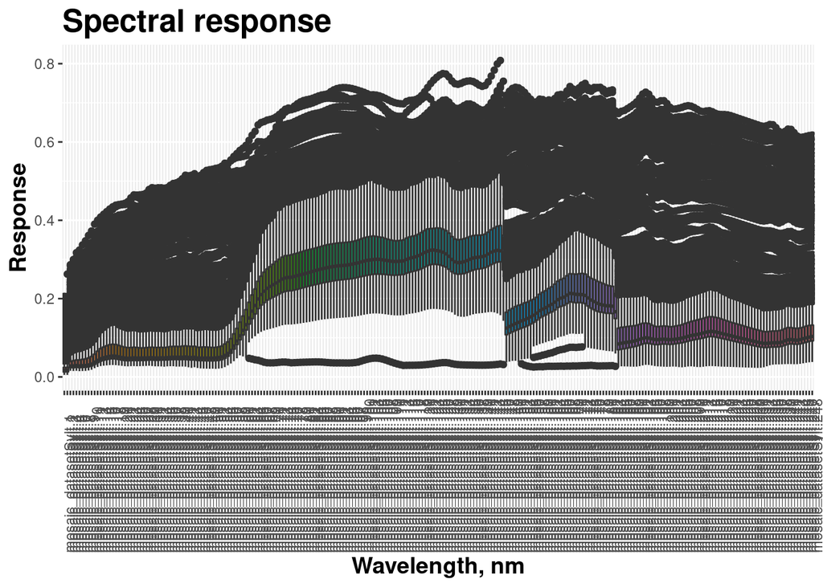

```r
setwd("/home/garzonc/Desktop/DIARS/")
spec <- read.table("PointBackground.csv", header = T, sep = " ")[, -c(2:3)]


library(reshape2)
library(ggplot2)
sample <- melt(spec, id = c("type"))

p <- ggplot(sample, aes(sample[, 2], sample[, 3])) + geom_boxplot(aes(fill = sample[,
    2]), outlier.colour = NULL) + theme(axis.text.x = element_text(angle = 90,
    hjust = 0), axis.title = element_text(face = "bold", size = 14), title = element_text(face = "bold",
    size = 16), legend.position = "none") + labs(title = paste("Spectral response"),
    x = "Wavelength, nm", y = "Response")
p
```

As you can see from the graph there is a large amount of data/information, this provides a huge potential and at the same time posits major limitations in time and processing power. One of the techniques most commonly used to reduce the dimension of the data, without loosing relevant information, is the Principal Components Analysis (PCA). Some of the variables (bands) might be highly correlated among them and so PCA allows extracting the most relevant variables (in form of components) from a large set of variables available in a data set. Calculate the PCA using the prcomp function using the already extracted values from the previous step:

```r
spec1 <- as.matrix(spec[, -c(1)])
pca <- prcomp(spec1, scale. = T, center = T)
summary(pca)  # Identify the coverage of variance in the dataset by individual principal components
```

[output not shown]

[output cut: 138 more lines]

```
## Standard deviation     5.448e-08 5.162e-08 5.034e-08 4.975e-08 4.88e-08
## Proportion of Variance 0.000e+00 0.000e+00 0.000e+00 0.000e+00 0.00e+00
## Cumulative Proportion  1.000e+00 1.000e+00 1.000e+00 1.000e+00 1.00e+00
##                            PC237     PC238     PC239     PC240     PC241
## Standard deviation     4.691e-08 4.627e-08 4.535e-08 4.334e-08 4.252e-08
## Proportion of Variance 0.000e+00 0.000e+00 0.000e+00 0.000e+00 0.000e+00
## Cumulative Proportion  1.000e+00 1.000e+00 1.000e+00 1.000e+00 1.000e+00
##                            PC242     PC243     PC244     PC245     PC246
## Standard deviation     4.088e-08 4.048e-08 3.951e-08 3.826e-08 3.728e-08
## Proportion of Variance 0.000e+00 0.000e+00 0.000e+00 0.000e+00 0.000e+00
## Cumulative Proportion  1.000e+00 1.000e+00 1.000e+00 1.000e+00 1.000e+00
##                           PC247     PC248
## Standard deviation     3.56e-08 3.516e-08
## Proportion of Variance 0.00e+00 0.000e+00
## Cumulative Proportion  1.00e+00 1.000e+00
```

```r
pca_red <- prcomp(spec1, scale. = T, center = T, tol = 0.01)  # Calculate only first components, tol=0
pca_red$sdev[1:11]
```

```
##  [1] 14.6289380  5.4588915  1.6463772  0.7934939  0.5126644  0.4478358
##  [7]  0.3043380  0.2620548  0.2009957  0.1922074  0.1700204
```

The PCA results shows the variance contained in the first component and the weight of each variable (band) contributing to the component. Based on those results we can exclude the bands that contribute the least.

**The artificial image is already provided as part of the tutorial dataset so you don’t need to perform the process explained below. This is only aimed to guide those interested in developing an artificial image with their own data**

##### Creating an artificial hyperspectral image - Optional (advanced GRASS GIS and bash programming skills)

**The artificial image developed as part of this dataset was created using GRASS GIS software. The following guide requires knowledge of GRASS GIS and bash programming**

The workflow presented here (Figure 4) summarizes the steps followed to generate an artificial image:

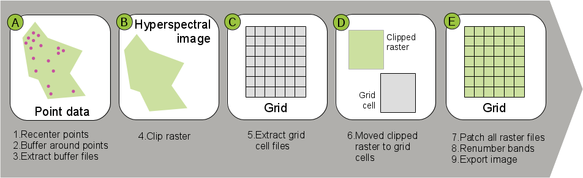

After location and mapset have been set, import the hyperspectral image and the point data which in this case correspond to the validation, calibration and background locations previously selected.

r.in.gdal -o input=mosaic_Sylt_20140716_v3.1 output=Sylt_mosaic

v.in.ogr input=/home/user/val_pointsDataset.shp output=val_points

Create buffer areas around the points in the point file. Make sure the point is in the middle of a pixel to ensure selecting the exact same number of pixels per buffer area.

%Convert points to raster to select the pixel that overlaps with the point

v.to.rast input=ALLpoints@Sylt type=point output=ALLpoints use=cat

%Convert raster back to points that will be located exactly at the center of the pixel

r.to.vect -v input=ALLpoints@Sylt output=ALLpointsUP type=point

%Create buffer area around the of 4.5 m distance around the recentered points

v.buffer -t input=ALLpointsUP@Sylt output=ALL_buffers distance=4.5

```
for i in `seq 1 646`; do
  v.extract input=ALL_buffers cats=`$`{i} output=Bufdata`$`{i} --o
done
```

Now each buffer area is in a single file but the buffer areas are circular, to convert them to squares you can use the following bash script:

```
for i in `seq 1 646`; do
  num=`expr $num + 1`
  g.region vector=Bufdata`$`{i} res=`$`PIXELSIZE -p
  v.in.region all_bufferUP_`$`num --o
done
```

%Set region back to the entire image

g.region raster=mosaic_Sylt_20140716_v3.1 -p

v.mkgrid –o map=ALL_buffers grid=34,35 position=coor coordinates=699402.6,6912889.5 box=9,9

Now each grid cell must be placed in a single file, to accomplish that you can use the same bash script used when extracting the buffer areas:

```
for i in `seq 1 646`; do
    v.extract input=ALL_buffers@Sylt cats=`$`{i} output=grid_`$`{i} --o
done
```

The next step is to clip the original raster image using the buffer area files and move those rasters to the a new grid cell. This process must be done per wavelength band (the hyperspectral image has a total of 248 bands), you can do it using the following bash script (the process might take a couple of days depending on the number of bands and buffer areas to clip and move):

```
x=0
for a in `seq 1 248`; do

  for i in `seq 1 646`; do
    g.region vector=all_bufferUP_`$`{i} -ap
    r.mask vect=all_bufferUP_`$`{i}
    echo "mosaic_Sylt_20140716_v3.`$`{a}"
    r.mapcalc expression="rast_buffer_`$`{a}_`$`{i} = mosaic_Sylt_20140716_v3.`$`{a}" --o
    r.mask -r
    x=`expr $x + 1`
    echo "grid `$`x"
    g.region vector=grid_`$`x
    g.region res=1.8 -ap
    eval `g.region -g`
    r.region map=rast_buffer_`$`{a}_`$`{i} n=`$`n s=n-9 w=e-9 e=`$`e
    g.region raster=mosaic -p
    echo "bufffer `$`{i} band `$`{a}"
    done

echo "Band `$`{a} and `$`x grids done"
x=0
echo "End `$`SECONDS seconds"
done
```

After all the clipped rasters have been move to the new grid, we can patch them into one single image (per wavelength band). The following bash script allows you to patch all the images and in all the bands. In this particular case we are patching 646 rasters, be careful to adapt the number sequence in this script when working with your own data:

```
for i in `seq 1 248`; do

  for a in `seq 1 248`; do
    MAPS1=`g.list -e type=raster sep=, pat="^rast_buffer_${a}_([1-9]|[1-9][0-9]|[1-5][0-9][0-9]|6[0-4][0-9])$"`
    g.region raster=$MAPS1
    r.patch in=$MAPS1 out=grid_mosaicC_1_${a} --o
    MAPS2=`g.list -e type=raster sep=, pat="^rast_buffer_${a}_([2-3][0-9][0-9])$"`
    g.region raster=$MAPS2
    r.patch in=$MAPS2 out=grid_mosaicC_2_${a} --o
    MAPS3=`g.list -e type=raster sep=, pat="^rast_buffer_${a}_([4-5][0-9][0-9])$"`
    g.region raster=$MAPS3
    r.patch in=$MAPS3 out=grid_mosaicC_3_${a} --o
    MAPS4=`g.list -e type=raster sep=, pat="^rast_buffer_${a}_(6[0-4][0-9])$"`
    g.region raster=$MAPS4
    r.patch in=$MAPS4 out=grid_mosaicC_4_${a} --o
  echo "grid_mosaicC_${a}"
  done
MAPS=`g.list -e type=raster sep=, pat="^grid_mosaicC_[1-4]_${i}$"`
g.region raster=$MAPS
r.patch in=$MAPS out=grid_mosaicC_all_${i} --o
echo "grid_mosaic_${i}"
done
```

The resulting artificial raster bands need to be renumbered to avoid misplacing when exporting the image as a tiff file. We will add 00 in front to have it organized in the right band order using the following bash script:

```
prefix="mosaicC_full_"

for map in `g.list type=raster pattern=${prefix}*`; do
  part=`echo $map | cut -d "_" -f 3`
  numero=`echo $part | awk '{ printf("%04d\n", $1) }'`
  names="${prefix}${numero}"
  g.rename raster=$map,$names
done
```

We can now verify that the hyperspectral artificial image has the correct band order, and if so, export it:

MAPS=`g.list type=raster sep=, pat="mosaicC_full_*"` i.group group=mosaic_datasetComp input=`$`MAPS

i.spectral -g group=mosaic_datasetComp@compiegne coordinates=699412.07161,6912899.83863

r.out.gdal in=mosaic_datasetComp out=mosaic_datasetComp.tiff -c –o

###### Back to the top

**Authors**: Carol Garzon-Lopez, Ruben Van De Kerchove, Duccio Rocchini & Jonathan Lenoir

**Date**: 2018-08-24

*Built with RMarkdown and hosted on Github Pages.*